# Modélisation des Séries Temporelles - Prix de l’or

## 7 - Backtesting

**Prévisons**

```r
Predictions <-forecast(model,h=length(gold.test$Date), level=c(95,99))
Predictions
```

```
##        Point Forecast    Lo 95    Hi 95    Lo 99    Hi 99
## Oct 58         1662.4 1623.760 1701.040 1611.619 1713.181
## Nov 58         1662.4 1607.755 1717.045 1590.585 1734.215
## Dec 58         1662.4 1595.474 1729.326 1574.445 1750.355
## Jan 59         1662.4 1585.121 1739.679 1560.838 1763.962
## Feb 59         1662.4 1575.999 1748.801 1548.850 1775.950
## Mar 59         1662.4 1567.753 1757.047 1538.013 1786.787
## Apr 59         1662.4 1560.169 1764.631 1528.046 1796.754
## May 59         1662.4 1553.111 1771.689 1518.770 1806.030
## Jun 59         1662.4 1546.481 1778.319 1510.057 1814.743
## Jul 59         1662.4 1540.211 1784.589 1501.817 1822.983
## Aug 59         1662.4 1534.247 1790.553 1493.979 1830.821
## Sep 59         1662.4 1528.549 1796.251 1486.490 1838.310
## Oct 59         1662.4 1523.083 1801.717 1479.307 1845.493
## Nov 59         1662.4 1517.824 1806.976 1472.395 1852.405
## Dec 59         1662.4 1512.750 1812.050 1465.726 1859.074
## Jan 60         1662.4 1507.842 1816.958 1459.276 1865.524
## Feb 60         1662.4 1503.085 1821.715 1453.025 1871.775
## Mar 60         1662.4 1498.466 1826.334 1446.955 1877.845
## Apr 60         1662.4 1493.974 1830.826 1441.051 1883.749
## May 60         1662.4 1489.599 1835.201 1435.301 1889.499
## Jun 60         1662.4 1485.331 1839.469 1429.692 1895.108
## Jul 60         1662.4 1481.165 1843.635 1424.216 1900.584
## Aug 60         1662.4 1477.091 1847.709 1418.863 1905.937
## Sep 60         1662.4 1473.106 1851.694 1413.625 1911.175
## Oct 60         1662.4 1469.202 1855.598 1408.495 1916.305
## Nov 60         1662.4 1465.376 1859.424 1403.467 1921.333
## Dec 60         1662.4 1461.623 1863.177 1398.534 1926.266
## Jan 61         1662.4 1457.939 1866.861 1393.693 1931.108
## Feb 61         1662.4 1454.320 1870.480 1388.936 1935.864
## Mar 61         1662.4 1450.763 1874.037 1384.261 1940.539
## Apr 61         1662.4 1447.264 1877.536 1379.664 1945.136
## May 61         1662.4 1443.822 1880.978 1375.140 1949.660
## Jun 61         1662.4 1440.433 1884.367 1370.686 1954.114
## Jul 61         1662.4 1437.095 1887.705 1366.299 1958.501
## Aug 61         1662.4 1433.805 1890.995 1361.976 1962.824
## Sep 61         1662.4 1430.563 1894.237 1357.714 1967.086
## Oct 61         1662.4 1427.365 1897.435 1353.512 1971.288
## Nov 61         1662.4 1424.210 1900.590 1349.365 1975.435
## Dec 61         1662.4 1421.096 1903.704 1345.273 1979.527
```

[output cut: 9 more lines]

```
## Oct 62         1662.4 1391.923 1932.877 1306.933 2017.867
## Nov 62         1662.4 1389.177 1935.623 1303.324 2021.476
## Dec 62         1662.4 1386.459 1938.341 1299.752 2025.049
## Jan 63         1662.4 1383.766 1941.034 1296.213 2028.587
## Feb 63         1662.4 1381.100 1943.700 1292.709 2032.091
## Mar 63         1662.4 1378.459 1946.341 1289.238 2035.562
## Apr 63         1662.4 1375.842 1948.958 1285.798 2039.002
## May 63         1662.4 1373.248 1951.552 1282.390 2042.410
## Jun 63         1662.4 1370.678 1954.122 1279.012 2045.788
## Jul 63         1662.4 1368.130 1956.670 1275.664 2049.136
## Aug 63         1662.4 1365.604 1959.196 1272.344 2052.456
## Sep 63         1662.4 1363.100 1961.701 1269.052 2055.748
## Oct 63         1662.4 1360.616 1964.184 1265.788 2059.012
## Nov 63         1662.4 1358.152 1966.648 1262.550 2062.250
## Dec 63         1662.4 1355.708 1969.092 1259.339 2065.461
```

[figure not shown]

```r
min <- min(Predictions$lower[,2])
max <- max(Predictions$upper[,2])
plot(x = gold.test$Date, y = gold.test$GC.F.Close, type='l', ylim = c(min, max), col="black")
lines(x = gold.test$Date, y = Predictions$mean, type = 'l', col="red")
lines(x = gold.test$Date, y = Predictions$lower[,1], lty=2, col="green")
lines(x = gold.test$Date, y = Predictions$upper[,1], lty=2, col="green")
lines(x = gold.test$Date, y = Predictions$lower[,2], lty=2, col="blue")
lines(x = gold.test$Date, y = Predictions$upper[,2], lty=2, col="blue")
legend("bottomleft", legend=c("Test Data", "Prediction", "Intervalle de prevision à 80%", "Intervall de Prévision à 90%"),
       col=c("black", "red", "green", "blue"), lty=c(1,1,2,2),cex = 0.5, )
grid(col = "lightgray", lty = "dotted")
```

[figure not shown]

```r
plot(x = gold$Date, y = gold$GC.F.Close, type='l', ylim = c(min, max), col="black")
abline(v = gold.test$Date[1], col = "blue")
lines(x = gold.test$Date, y = Predictions$mean, type = 'l', col="red")
lines(x = gold.test$Date, y = Predictions$lower[,1], lty=2, col="green")
lines(x = gold.test$Date, y = Predictions$upper[,1], lty=2, col="green")
lines(x = gold.test$Date, y = Predictions$lower[,2], lty=2, col="blue")
lines(x = gold.test$Date, y = Predictions$upper[,2], lty=2, col="blue")
legend("bottomleft", legend=c("Real data", "Prediction", "Intervalle de prevision à 80%", "Intervall de Prévision à 90%"),
       col=c("black", "red", "green", "blue"), lty=c(1,1,2,2),cex = 0.8)
grid(col = "lightgray", lty = "dotted")
```

**Evaluation du modèle**

```r
error <- Predictions$mean - gold.test$GC.F.Close
summary(error)
```

```
##    Min. 1st Qu.  Median    Mean 3rd Qu.    Max.
## -157.30 -123.85  -82.50  -67.27   -6.25   35.10
```

```r
MAE <- mean(abs(error))
MAE
```

```
## [1] 75.5492
```

```r
MSE <- mean(error^2)
MSE
```

```
## [1] 8395.167
```

```r
RMSE <- sqrt(MSE)
RMSE
```

```
## [1] 91.62514
```

**Critique**

Le modèle proposé n’est pas un bon modèle. En effet, la prévision du marché des prix de l’or est beaucoup plus complexe et nécessite des modèles plus complexe qu’un SARIMA. Aussi, il ne faut pas oublier les évenements brusque qui inflencent le marché et qui ne peuvent pas être prédite à l’avance. Notons aussi que la taille des données est petite et qu’ils tombent sur période anomalie (COVID) qui a influencé faussement le modèle.

# 8 - Amélioration ..?

Comme j’ai signalé au début, la période 2020 était marqué par la crise sanitaire du COVID19. Ainsi, je vais supprimer la période janvier 2020 - mars 2020 dans l’espoir d’améliorer le modèle. En fait, l’idée est de supprimer les données anomalitiques et qui influent l’apprentissage.

**Première Amélioration**

On impose une saisonalité à auto.arima()

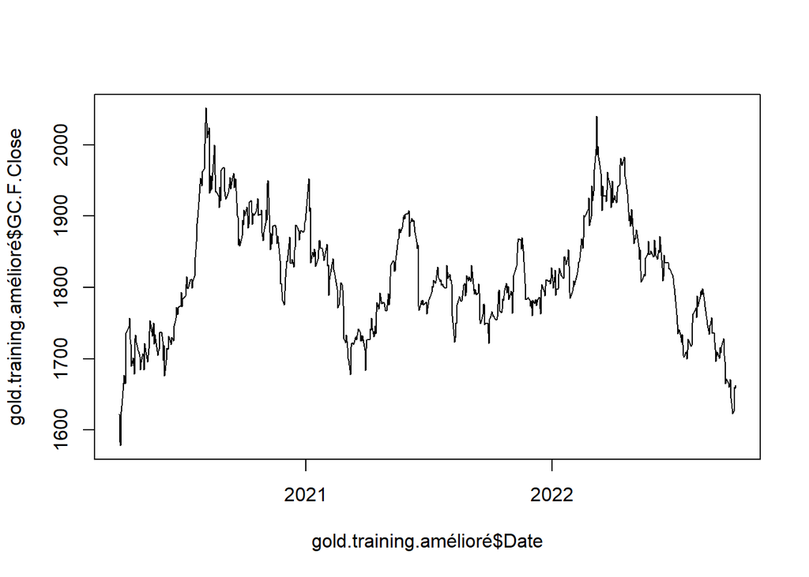

```r
gold.training.amélioré <- gold.training[gold.training$Date >= "2020-03-30",]
plot(x= gold.training.amélioré$Date, y = gold.training.amélioré$GC.F.Close, type= 'l')
```

```r
data.amélioré <- ts(gold.training.amélioré$GC.F.Close, frequency = 12)
data.amélioré <- na.omit(data.amélioré)
model.amélioré <- auto.arima(data.amélioré, D=1, trace = TRUE, approximation = FALSE,allowdrift = T,allowmean = T)
```

```
##
##  ARIMA(2,0,2)(1,1,1)[12] with drift         : Inf
##  ARIMA(0,0,0)(0,1,0)[12] with drift         : 6785.858
##  ARIMA(1,0,0)(1,1,0)[12] with drift         : 5635.262
##  ARIMA(0,0,1)(0,1,1)[12] with drift         : 6256.63
##  ARIMA(0,0,0)(0,1,0)[12]                    : 6783.855
##  ARIMA(1,0,0)(0,1,0)[12] with drift         : 5789.051
##  ARIMA(1,0,0)(2,1,0)[12] with drift         : 5586.848
##  ARIMA(1,0,0)(2,1,1)[12] with drift         : Inf
##  ARIMA(1,0,0)(1,1,1)[12] with drift         : Inf
##  ARIMA(0,0,0)(2,1,0)[12] with drift         : 6785.808
##  ARIMA(2,0,0)(2,1,0)[12] with drift         : Inf
##  ARIMA(1,0,1)(2,1,0)[12] with drift         : 5587.273
##  ARIMA(0,0,1)(2,1,0)[12] with drift         : 6258.852
##  ARIMA(2,0,1)(2,1,0)[12] with drift         : 5589.131
##  ARIMA(1,0,0)(2,1,0)[12]                    : 5584.818
##  ARIMA(1,0,0)(1,1,0)[12]                    : 5633.238
##  ARIMA(1,0,0)(2,1,1)[12]                    : Inf
##  ARIMA(1,0,0)(1,1,1)[12]                    : Inf
##  ARIMA(0,0,0)(2,1,0)[12]                    : 6783.789
##  ARIMA(2,0,0)(2,1,0)[12]                    : Inf
##  ARIMA(1,0,1)(2,1,0)[12]                    : 5585.237
##  ARIMA(0,0,1)(2,1,0)[12]                    : 6256.82
##  ARIMA(2,0,1)(2,1,0)[12]                    : 5587.086
##
##  Best model: ARIMA(1,0,0)(2,1,0)[12]
```

```r
model.amélioré
```

```
## Series: data.amélioré
## ARIMA(1,0,0)(2,1,0)[12]
##
## Coefficients:
##          ar1     sar1     sar2
##       0.9464  -0.6261  -0.2880
## s.e.  0.0133   0.0395   0.0395
##
## sigma^2 = 462.3:  log likelihood = -2788.38
## AIC=5584.75   AICc=5584.82   BIC=5602.48
```

```r
Predictions.amélioré <-forecast(model.amélioré,h=length(gold.test$Date), level=c(95,99))
Predictions.amélioré
```

```
##        Point Forecast    Lo 95    Hi 95    Lo 99    Hi 99
## Oct 53       1653.320 1611.178 1695.463 1597.936 1708.705
## Nov 53       1657.568 1599.547 1715.590 1581.315 1733.822
## Dec 53       1650.694 1581.477 1719.912 1559.727 1741.661
## Jan 54       1643.882 1565.992 1721.771 1541.517 1746.246
## Feb 54       1649.732 1564.824 1734.640 1538.143 1761.320
## Mar 54       1650.528 1559.793 1741.262 1531.282 1769.773
## Apr 54       1646.743 1551.091 1742.394 1521.035 1772.450
## May 54       1634.905 1535.055 1734.755 1503.680 1766.130
## Jun 54       1645.259 1541.793 1748.724 1509.282 1781.236
## Jul 54       1664.653 1558.053 1771.252 1524.557 1804.749
## Aug 54       1661.334 1552.004 1770.664 1517.650 1805.019
## Sep 54       1655.921 1544.202 1767.640 1509.097 1802.745
## Oct 54       1644.260 1526.414 1762.106 1489.384 1799.136
## Nov 54       1646.110 1523.036 1769.185 1484.363 1807.858
## Dec 54       1640.570 1512.995 1768.146 1472.907 1808.233
## Jan 55       1632.943 1501.467 1764.419 1460.154 1805.732
## Feb 55       1642.277 1507.404 1777.150 1465.024 1819.531
## Mar 55       1643.561 1505.716 1781.406 1462.402 1824.720
## Apr 55       1639.328 1498.875 1779.781 1454.742 1823.915
## May 55       1626.792 1484.044 1769.541 1439.189 1814.395
## Jun 55       1635.529 1490.756 1780.302 1445.265 1825.793
## Jul 55       1658.882 1512.319 1805.445 1466.266 1851.498
## Aug 55       1651.558 1503.411 1799.705 1456.860 1846.257
## Sep 55       1649.552 1500.000 1799.104 1453.007 1846.097
## Oct 55       1634.251 1479.572 1788.929 1430.969 1837.533
## Nov 55       1639.221 1480.091 1798.351 1430.089 1848.353
## Dec 55       1634.214 1471.201 1797.227 1419.979 1848.449
## Jan 56       1628.108 1461.694 1794.521 1409.403 1846.812
## Feb 56       1635.858 1466.456 1805.260 1413.226 1858.489
## Mar 56       1639.217 1467.183 1811.251 1413.126 1865.308
## Apr 56       1629.790 1455.433 1804.147 1400.646 1858.934
## May 56       1615.502 1439.090 1791.915 1383.657 1847.347
## Jun 56       1623.947 1445.715 1802.180 1389.710 1858.185
## Jul 56       1649.604 1469.757 1829.451 1413.245 1885.963
## Aug 56       1645.822 1464.541 1827.103 1407.578 1884.065
## Sep 56       1644.957 1462.402 1827.513 1405.039 1884.876
## Oct 56       1633.239 1445.129 1821.349 1386.021 1880.458
## Nov 56       1637.477 1444.528 1830.426 1383.899 1891.055
## Dec 56       1632.254 1435.072 1829.436 1373.113 1891.395
```

[output cut: 9 more lines]

```
## Oct 57       1631.653 1408.626 1854.680 1338.546 1924.760
## Nov 57       1635.724 1408.825 1862.624 1337.528 1933.921
## Dec 57       1630.742 1400.430 1861.054 1328.060 1933.424
## Jan 58       1624.352 1391.025 1857.679 1317.709 1930.995
## Feb 58       1632.954 1396.960 1868.948 1322.806 1943.102
## Mar 58       1635.555 1397.199 1873.912 1322.302 1948.809
## Apr 58       1629.247 1388.794 1869.701 1313.238 1945.257
## May 58       1616.288 1373.973 1858.604 1297.831 1934.745
## Jun 58       1625.381 1381.409 1869.353 1304.747 1946.014
## Jul 58       1649.712 1404.267 1895.157 1327.142 1972.282
## Aug 58       1644.799 1398.042 1891.557 1320.505 1969.094
## Sep 58       1643.244 1395.317 1891.171 1317.412 1969.075
## Oct 58       1630.304 1378.371 1882.237 1299.208 1961.400
## Nov 58       1634.832 1379.365 1890.299 1299.091 1970.573
## Dec 58       1629.895 1371.303 1888.487 1290.048 1969.742
```

[figure not shown]

```r
min <- min(Predictions.amélioré$lower[,2])
max <- max(Predictions.amélioré$upper[,2])
plot(x = gold.test$Date, y = gold.test$GC.F.Close, type='l', ylim = c(min, max), col="black", main = "Prévisions du modèle amélioré")
lines(x = gold.test$Date, y = Predictions.amélioré$mean, type = 'l', col="red")
lines(x = gold.test$Date, y = Predictions.amélioré$lower[,1], lty=2, col="green")
lines(x = gold.test$Date, y = Predictions.amélioré$upper[,1], lty=2, col="green")
lines(x = gold.test$Date, y = Predictions.amélioré$lower[,2], lty=2, col="blue")
lines(x = gold.test$Date, y = Predictions.amélioré$upper[,2], lty=2, col="blue")
legend("bottomleft", legend=c("Real data", "Prediction", "Intervalle de prevision à 80%", "Intervall de Prévision à 90%"),
       col=c("black", "red", "green", "blue"), lty=c(1,1,2,2),cex = 0.4)
grid(col = "lightgray", lty = "dotted")
```

```r
error.amélioré <- Predictions.amélioré$mean - gold.test$GC.F.Close
summary(error.amélioré)
```

```
##    Min. 1st Qu.  Median    Mean 3rd Qu.    Max.
## -199.61 -146.91 -107.42  -90.64  -23.06   22.95
```

```r
MAE.amélioré <- mean(abs(error.amélioré))
MAE.amélioré
```

```
## [1] 94.07268
```

```r
MSE.amélioré <- mean(error.amélioré^2)
MSE.amélioré
```

```
## [1] 12888.21
```

```r
RMSE.amélioré <- sqrt(MSE.amélioré)
RMSE.amélioré
```

```
## [1] 113.5263
```

**Deuxième Amélioration**

```r
model.amélioré2 <- auto.arima(data.amélioré)
model.amélioré2
```

```
## Series: data.amélioré
## ARIMA(2,0,2)(1,0,0)[12] with non-zero mean
##
## Coefficients:
##          ar1     ar2     ma1      ma2    sar1       mean
##       0.2555  0.7113  0.6750  -0.0609  0.0255  1794.4216
## s.e.  0.2590  0.2529  0.2604   0.0396  0.0418    35.0211
##
## sigma^2 = 350.9:  log likelihood = -2751.63
## AIC=5517.25   AICc=5517.43   BIC=5548.41
```

```r
Predictions.amélioré2 <-forecast(model.amélioré2,h=length(gold.test$Date), level=c(95,99))
Predictions.amélioré2
```

```
##        Point Forecast    Lo 95    Hi 95    Lo 99    Hi 99
## Oct 53       1664.609 1627.893 1701.324 1616.357 1712.861
## Nov 53       1666.705 1616.554 1716.855 1600.795 1732.614
## Dec 53       1669.328 1609.509 1729.147 1590.713 1747.943
## Jan 54       1671.244 1603.105 1739.384 1581.694 1760.795
## Feb 54       1673.868 1598.788 1748.948 1575.196 1772.540
## Mar 54       1676.146 1594.816 1757.475 1569.261 1783.030
## Apr 54       1677.812 1590.982 1764.642 1563.699 1791.926
## May 54       1679.350 1587.481 1771.219 1558.614 1800.086
## Jun 54       1681.623 1585.195 1778.050 1554.895 1808.350
## Jul 54       1684.535 1583.890 1785.180 1552.265 1816.805
## Aug 54       1686.565 1582.043 1791.088 1549.199 1823.931
## Sep 54       1688.656 1580.522 1796.789 1546.544 1830.768
## Oct 54       1690.699 1578.979 1802.419 1543.874 1837.524
## Nov 54       1692.676 1577.617 1807.735 1541.463 1843.890
## Dec 54       1694.648 1576.476 1812.820 1539.343 1849.953
## Jan 55       1696.552 1575.454 1817.649 1537.402 1855.701
## Feb 55       1698.447 1574.606 1822.289 1535.692 1861.203
## Mar 55       1700.292 1573.864 1826.720 1534.137 1866.447
## Apr 55       1702.092 1573.227 1830.957 1532.735 1871.449
## May 55       1703.851 1572.684 1835.018 1531.468 1876.234
## Jun 55       1705.598 1572.255 1838.941 1530.355 1880.841
## Jul 55       1707.327 1571.923 1842.731 1529.376 1885.278
## Aug 55       1709.003 1571.647 1846.359 1528.487 1889.520
## Sep 55       1710.648 1571.440 1849.857 1527.697 1893.600
## Oct 55       1712.263 1571.292 1853.234 1526.995 1897.530
## Nov 55       1713.845 1571.199 1856.490 1526.377 1901.312
## Dec 55       1715.397 1571.160 1859.635 1525.837 1904.957
## Jan 56       1716.919 1571.166 1862.671 1525.367 1908.470
## Feb 56       1718.412 1571.217 1865.607 1524.965 1911.859
## Mar 56       1719.876 1571.307 1868.445 1524.623 1915.129
## Apr 56       1721.312 1571.433 1871.191 1524.337 1918.286
## May 56       1722.720 1571.591 1873.848 1524.103 1921.336
## Jun 56       1724.101 1571.781 1876.421 1523.918 1924.284
## Jul 56       1725.456 1571.998 1878.914 1523.778 1927.134
## Aug 56       1726.784 1572.240 1881.329 1523.679 1929.890
## Sep 56       1728.087 1572.505 1883.669 1523.618 1932.557
## Oct 56       1729.365 1572.791 1885.939 1523.592 1935.138
## Nov 56       1730.618 1573.096 1888.140 1523.599 1937.637
## Dec 56       1731.847 1573.419 1890.276 1523.637 1940.058
```

[output cut: 9 more lines]

```
## Oct 57       1742.908 1577.299 1908.517 1525.261 1960.555
## Nov 57       1743.900 1577.729 1910.072 1525.514 1962.287
## Dec 57       1744.874 1578.162 1911.585 1525.778 1963.969
## Jan 58       1745.828 1578.600 1913.057 1526.053 1965.604
## Feb 58       1746.764 1579.040 1914.489 1526.337 1967.191
## Mar 58       1747.682 1579.482 1915.882 1526.630 1968.735
## Apr 58       1748.583 1579.926 1917.239 1526.930 1970.235
## May 58       1749.466 1580.371 1918.560 1527.238 1971.693
## Jun 58       1750.331 1580.817 1919.846 1527.552 1973.111
## Jul 58       1751.181 1581.264 1921.098 1527.872 1974.490
## Aug 58       1752.014 1581.710 1922.317 1528.197 1975.831
## Sep 58       1752.831 1582.156 1923.505 1528.526 1977.135
## Oct 58       1753.632 1582.601 1924.663 1528.859 1978.405
## Nov 58       1754.418 1583.045 1925.790 1529.196 1979.640
## Dec 58       1755.188 1583.487 1926.889 1529.535 1980.841
```

[figure not shown]

```r
min <- min(Predictions.amélioré2$lower[,2])
max <- max(Predictions.amélioré2$upper[,2])
plot(x = gold.test$Date, y = gold.test$GC.F.Close, type='l', ylim = c(min, max), col="black", main = "Prévisions du modèle amélioré 2.0")
lines(x = gold.test$Date, y = Predictions.amélioré2$mean, type = 'l', col="red")
lines(x = gold.test$Date, y = Predictions.amélioré2$lower[,1], lty=2, col="green")
lines(x = gold.test$Date, y = Predictions.amélioré2$upper[,1], lty=2, col="green")
lines(x = gold.test$Date, y = Predictions.amélioré2$lower[,2], lty=2, col="blue")
lines(x = gold.test$Date, y = Predictions.amélioré2$upper[,2], lty=2, col="blue")
legend("bottomleft", legend=c("Real data", "Prediction", "Intervalle de prevision à 80%", "Intervalle de Prévision à 90%"),
       col=c("black", "red", "green", "blue"), lty=c(1,1,2,2),cex = 0.4)
grid(col = "lightgray", lty = "dotted")
```

```r
error.amélioré2 <- Predictions.amélioré2$mean - gold.test$GC.F.Close
summary(error.amélioré2)
```

```
##    Min. 1st Qu.  Median    Mean 3rd Qu.    Max.
##  -69.03  -46.46  -26.63  -11.46   32.93   83.35
```

```r
MAE.amélioré2 <- mean(abs(error.amélioré2))
MAE.amélioré2
```

```
## [1] 40.40023
```

```r
MSE.amélioré2 <- mean(error.amélioré2^2)
MSE.amélioré2
```

```
## [1] 2033.916
```

```r
RMSE.amélioré2 <- sqrt(MSE.amélioré2)
RMSE.amélioré2
```

```
## [1] 45.09895
```

**Comparaison des modèles**

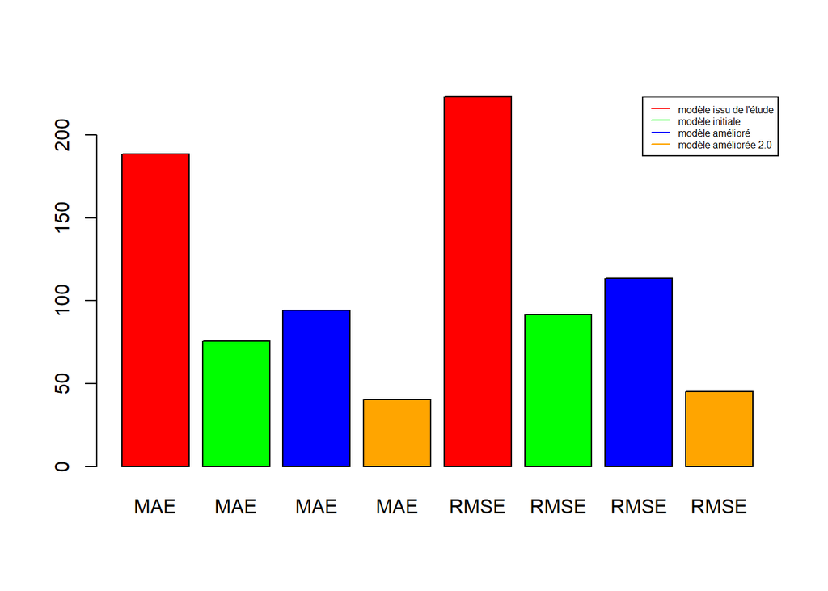

```r
x <- c("MAE","MAE","MAE","MAE","RMSE", "RMSE", "RMSE", "RMSE")
y <- c(MAE.etude,MAE, MAE.amélioré, MAE.amélioré2,RMSE.etude, RMSE, RMSE.amélioré, RMSE.amélioré2)
barplot(y , names.arg=x, col= c("red","green","blue","orange"))
legend("topright", legend = c("modèle issu de l'étude","modèle initiale", "modèle amélioré", "modèle améliorée 2.0"), col=c("red","green","blue","orange"),lty= 1, cex=0.5)
```

# 9 - Goodness of Fit

D’après la figure de comparaison des modèle, on conclut qu’une approximation du **goodness of fit** est donnée par le dernier modèle ARIMA(2,0,2)(1,0,0)[12]. L’erreur moyenne du modèle est entre 40 et 45 dollars, donc ce modèle n’est pas mauvais puisque le prix de l’or par ounce est de l’ordre de 2000 dollars.  
Aussi, la prévision de ce modèle montre une tendance croissante. Ainsi, pour un acheteur, il s’avère mieux de le faire au début. Pour un vendeur, le faire vers la fin. Aussi, la stratégie la plus logique est “go long”.